# Basics in R

Daniel Winkler

May 7, 2018

## Preliminaries

- Material Online:

  `tinyurl.com/basicrwu2018`
- Links to software, data, code, info, …
- *Go there now!*

## R and R-Studio

- R is the interpreter
- R is free as in freedom
- We can view & edit the sourcecode
- R-Studio is the user interface
- It enables us to easily interact with an R process
- We could use other interfaces like emacs, jupyter …
- *Install R and R-Studio*
- Material Online:

  `tinyurl.com/basicrwu2018`

## Objectives

- Understand the R syntax
- Know the data structures and types
- Understand functions and how we can work with them
- Learn about data visualization
- Learn how to get and use extensions (“Packages”)
- Use easily understandable data to get to know complicated concepts
- … so we can then use them for unknown/complicated data
- Read and understand some error messages and learn how to fix them
- Do whatever YOU are interested in

## Exercise 1

1. Open R-Studio
2. Create a new R script
3. Check out the 4 “Panes”
   - Right now we need the two on the left
   - What is the difference between them?
4. Type *something* in the script and save it

## Exercise 2

1. Create two *numeric* variables and apply a function that uses both of them as inputs
2. Create a vector $x$ and a matrix $A$ and calculate $y = x'A$

$$x = \begin{bmatrix}
1 \\
2 \\
3
\end{bmatrix}$$

$$A = \begin{bmatrix}
1 & 2 & 3\\
4 & 5 & 6\\
7 & 8 & 10\\
\end{bmatrix}$$

3. Calculate the square of each value in the vector $y$
4. Create and save a character vector with the first 20 lower case letters of the alphabet
5. Print ‘“c” “d” “e” “h”’ by extracting them from the vector
6. Bonus: Print the 2nd column and the 3rd row of $A$. Print the element in the 2nd column and 3rd row

## Solution 2

```r
# 1. Create two *numeric* variables and apply a function that uses both of them as inputs
a <- 3.14159
b <- exp(1)
## Is pi > eulers number?
ifelse(a>b, yes = TRUE, no = FALSE)
```

```
## [1] TRUE
```

```r
# 2. Create a vector x and a matrix A and calculate y = x'A
x <- 1:3
A <- matrix(c(1:8, 10), nrow = 3, byrow = TRUE)
y <- t(x) %*% A
y
```

```
##      [,1] [,2] [,3]
## [1,]   30   36   45
```

```r
# Alternative:
x %*% A
```

```
##      [,1] [,2] [,3]
## [1,]   30   36   45
```

```r
# Note: Default is inner product for vectors
x %*% x
```

```
##      [,1]
## [1,]   14
```

```r
# 3. Calculate the square of each value in the vector y
y^2
```

```
##      [,1] [,2] [,3]
## [1,]  900 1296 2025
```

```r
# 4. Create and save a character vector with the first 20 lower case letters of the alphabet
c <- letters[1:20]

# 5. Print '"c" "d" "e" "h"' by extracting them from the vector
c[c(3:5, 8)]
```

```
## [1] "c" "d" "e" "h"
```

```r
# 6. Bonus: Print the 2nd column and the 3rd row of $A$. Print the element in the 2nd column and 3rd row
A
```

```
##      [,1] [,2] [,3]
## [1,]    1    2    3
## [2,]    4    5    6
## [3,]    7    8   10
```

```r
A[ , 2]
```

```
## [1] 2 5 8
```

```r
A[3, ]
```

```
## [1]  7  8 10
```

```r
A[3, 2]
```

```
## [1] 8
```

## Exercise 3

1. Create a `data.frame` with 100 observations of one numeric and one categorial variable with 3 groups. Give each a meaningful name!
2. Print the numeric column using the `$` and the `[` operators.
3. Calculate and save the mean of the numeric column.
4. Change the 5th value in the numeric column to the mean of the column. Use the `head` function to check if it worked.
5. Create a boxplot of the numeric variable for each group
6. Create a line plot of the numeric values for each group. Sort the values, set a title and add a legend!

## Solution 3

```r
#1. Create a data.frame with 100 observations of one numeric and one categorial variable with 3 groups.
df <- data.frame(value = rnorm(100),
                 group = sample(c('a', 'b', 'c'), size = 100, replace = TRUE))

#2. Print the numeric column using the $ and the [ operators.
head(df$v)
```

```
## [1]  1.271409e+00  6.449964e-01  2.099275e-02 -7.466615e-05 -3.158308e-01
## [6]  1.134936e+00
```

```r
head(df['value'])
```

```
##           value
## 1  1.271409e+00
## 2  6.449964e-01
## 3  2.099275e-02
## 4 -7.466615e-05
## 5 -3.158308e-01
## 6  1.134936e+00
```

```r
#3. Calculate and save the mean of the numeric column.
(m <- mean(df$value))
```

```
## [1] -0.009818701
```

```r
#4. Change the 5th value in the numeric column to the mean. Use the head function to check if it worked.
df$value[5] <- m
head(df$value)
```

```
## [1]  1.271409e+00  6.449964e-01  2.099275e-02 -7.466615e-05 -9.818701e-03
## [6]  1.134936e+00
```

```r
# Alternatives:
df[5, 1]
```

```
## [1] -0.009818701
```

```r
df[['value']][5]
```

```
## [1] -0.009818701
```

```r
df['value'][5, 1]
```

```
## [1] -0.009818701
```

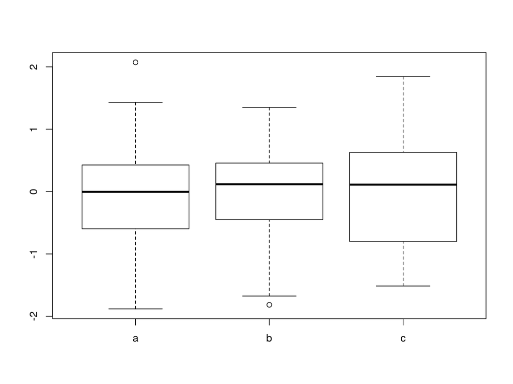

```r
#5. Create a boxplot of the numeric variable for each group
boxplot(df$value~df$group)
```

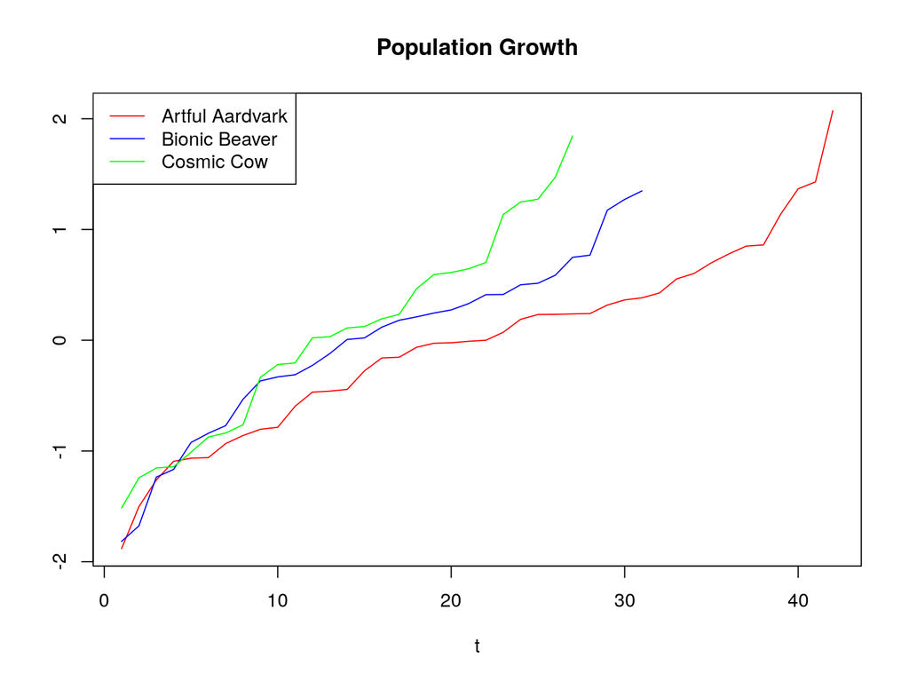

```r
#6. Create a line plot of the numeric values for each group. Sort the values, add a title and a legend!
df <- df[order(df$value),]
plot(df$value[df$group == 'a'], col = 'red', type = 'l', main = "Population Growth",
     xlab = 't', ylab = '')
lines(df$value[df$group == 'b'], col = 'blue')
lines(df$value[df$group == 'c'], col = 'green')
legend(x = 'topleft',
       legend = c('Artful Aardvark', 'Bionic Beaver', 'Cosmic Cow'),
       lty = 1, col=c('red', 'blue', 'green'))
```